# R Notebook

- correlation
- similarity measures
- plotting similarity

This session is based on chapter 6 of Levshina’s *How to do linguistics with R*. One of the aims of this course is that you should be able to go into any chapter of this textbook and follow the methods

Install the `Rling` package from https://benjamins.com/sites/z.195/content/package.html (or search *Rling download*).

Load up everything we need

```r
library(tidyverse)
library(Rling)
data(ldt) # lexical decision time data
```

Check out the data:

```r
head(ldt)
```

|  | Length | Freq | Mean_RT |
| --- | --- | --- | --- |
| marveled | 8 | 131 | 819.2 |
| persuaders | 10 | 82 | 977.6 |
| midmost | 7 | 0 | 908.2 |
| crutch | 6 | 592 | 766.3 |
| resuspension | 12 | 2 | 1125.4 |
| efflorescent | 12 | 9 | 948.3 |

Plot word length against reaction time.

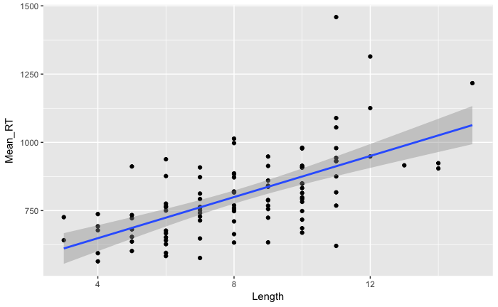

```r
ldt %>% ggplot(aes(x=Length, y=Mean_RT)) + geom_point() + geom_smooth(method="lm")
```

Intro to linear regression

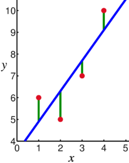

Linear regression assumes that the observations (red points) show an underlying relationship between x and y (the blue line), which is obscured by some noise/random/other factors (green lines, called **residuals**). The residuals are the deviations from perfect correlation.

This contains all the data. You can look at the residuals:

```r
#residuals(m) %>% head()
m$residuals %>% head()
```

```
    marveled   persuaders      midmost       crutch resuspension efflorescent
      19.595      102.747      146.269       41.993      175.249       -1.841
```

Or plot them (use a histogram)

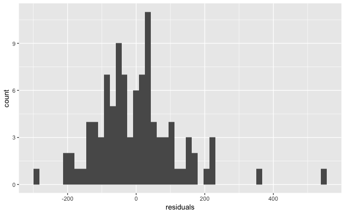

```r
tibble(residuals=residuals(m)) %>% ggplot(aes(x=residuals)) + geom_histogram(bins=50)
```

Measure the correlation (using *least squares*, minimising the squares of the residuals)

```r
cor(ldt$Mean_RT, ldt$Length)
```

```
[1] 0.6147
```

```r
#help(cor)
#cor(Mean_RT, Length, data=ldt)
```

Test the strength of this correlation. Basically, is zero within the 95% confidence interval?

```r
cor.test(ldt$Mean_RT, ldt$Length, alternative="greater")
```

```
    Pearson's product-moment correlation

data:  ldt$Mean_RT and ldt$Length
t = 7.7, df = 98, p-value = 5e-12
alternative hypothesis: true correlation is greater than 0
95 percent confidence interval:
 0.5001 1.0000
sample estimates:
   cor
0.6147
```

Very high probability that the true correlation is greater than zero.

Compare with some random data:

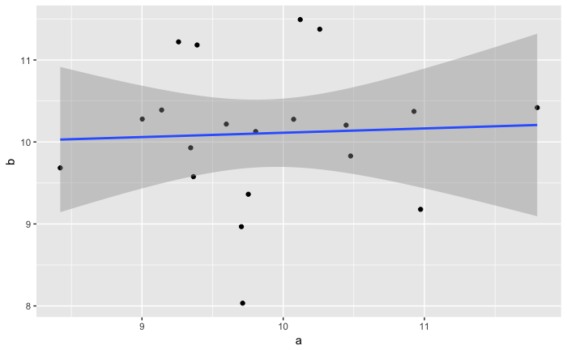

```r
ran.data <- tibble(a=rnorm(20, 10, 1), b=rnorm(20, 10, 1))
ran.data %>% ggplot(aes(x=a, y=b)) + geom_point() + geom_smooth(method="lm")
```

There might seem to be a correlation:

[output not shown]

But do we believe this? (use two-sided alternative: testing that the value is not zero)

```r
cor.test(ran.data$a, ran.data$b, alternative="two.sided")
```

```
    Pearson's product-moment correlation

data:  ran.data$a and ran.data$b
t = 0.21, df = 18, p-value = 0.8
alternative hypothesis: true correlation is not equal to 0
95 percent confidence interval:
 -0.4028  0.4805
sample estimates:
    cor
0.04828
```

(at the p-value cut-off of 0.05, one in twenty times this demo won’t work)

```r
ran.data <- tibble(a=runif(100, 0, 20))
#head(ran.data)
ran.data$b <- ran.data$a + rnorm(100, 0, 10)
head(ran.data)
```

| a | b |
| --- | --- |
| 7.849 | -2.110 |
| 4.061 | -5.208 |
| 10.716 | 13.158 |
| 13.072 | 8.097 |
| 17.064 | 21.676 |
| 5.226 | 5.195 |

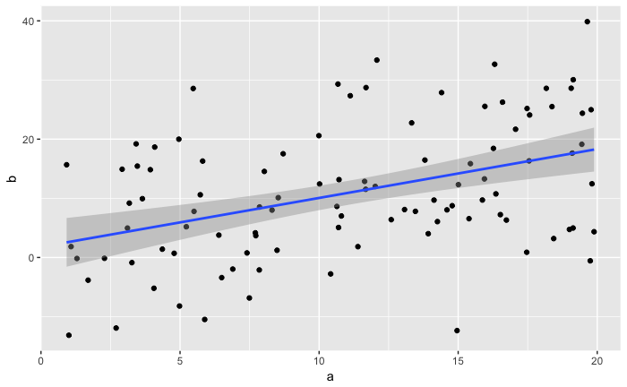

```r
ran.data %>% ggplot(aes(x=a, y=b)) + geom_point() + geom_smooth(method="lm")
```

[figure not shown]

Discussion point:

- don’t confuse effect size with statistical significance!

## Outliers

- False correlations with outliers

Add an outlier

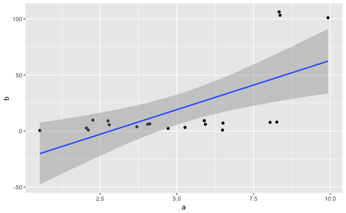

```r
ran.data <- tibble(a=runif(20, 0, 10), b=runif(20, 0, 10))
ran.data %>%
  arrange(desc(a)) %>%
  mutate(rank=1:n()) %>%
  mutate(b=if_else(rank < 4, b+100, b)) -> ran.data.2
ran.data.2 %>% ggplot(aes(x=a, y=b)) + geom_point() + geom_smooth(method="lm")
```

```r
cor(ran.data.2$a, ran.data.2$b)
```

```
[1] 0.6366
```

```r
cor.test(ran.data.2$a, ran.data.2$b, alternative="two.sided")
```

```
    Pearson's product-moment correlation

data:  ran.data.2$a and ran.data.2$b
t = 3.5, df = 18, p-value = 0.003
alternative hypothesis: true correlation is not equal to 0
95 percent confidence interval:
 0.2702 0.8420
sample estimates:
   cor
0.6366
```

[output not shown]

**Solution:** remove outliers

- Check ldt data for outliers in mean_RT
- What might these mean?
- Remove outliers and recalculate correlation

## Assumptions of Pearson correlation

- The sample is randomly selected from the population it represents
- Both variables are interval-scaled
- The sample size is large (> 30); or for smaller samples, both variables come from a bivariate normal distribution. This means: both variables are normally distributed, and their linear combination is also normally distributed.
- The residual variance is *homoscedastic*). This means: the relationship between the variables is of equal strength across the entire range of both variables
- The residuals are independent (no autocorrelation)

## Distance

**From here on is for Session #8**

Data from [The World Atlas of Linguistic Structures](https://wals.info)

```r
wals <- read_tsv("./typ/wals_data.tsv")
head(wals)
```

| wals.code | name | family | F82A | F83A | F85A | F86A | F87A | F88A | F89A | F90A |
| --- | --- | --- | --- | --- | --- | --- | --- | --- | --- | --- |
| aab | Arapesh (Abu) | Torricelli | 1 | 2 | NA | NA | 2 | 2 | 2 | NA |
| aar | Aari | Afro-Asiatic | 1 | 1 | 1 | 1 | 2 | 2 | 2 | 1 |
| aba | Abau | Sepik | 1 | 1 | 1 | 1 | NA | 2 | 2 | NA |
| abi | Abipón | Guaicuruan | 1 | 2 | 2 | 3 | 3 | 1 | NA | 1 |
| abk | Abkhaz | Northwest Caucasian | 1 | 1 | 1 | 1 | 2 | 1 | 3 | 2 |
| abn | Arabana | Pama-Nyungan | 1 | 1 | NA | 3 | 2 | NA | NA | NA |

Check the data quality. How much is missing?

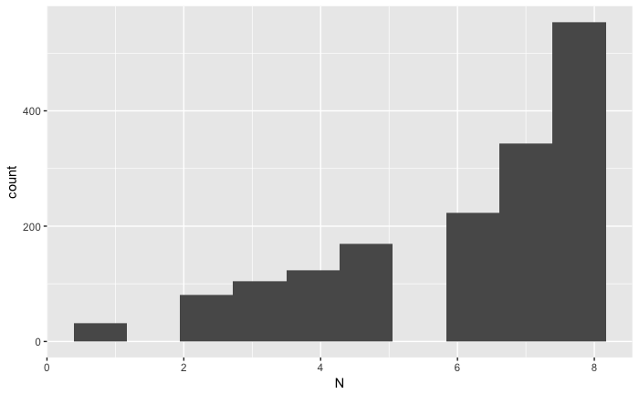

```r
wals %>% group_by(wals.code) %>%
  mutate(N=sum(!is.na(F82A), !is.na(F83A), !is.na(F85A), !is.na(F86A), !is.na(F87A), !is.na(F88A), !is.na(F89A), !is.na(F90A))) %>%
  ggplot(aes(x=N)) + geom_histogram(bins=10)
```

Let’s just take the complete samples

```r
wals %>% group_by(wals.code) %>%
  mutate(N=sum(!is.na(F82A), !is.na(F83A), !is.na(F85A), !is.na(F86A), !is.na(F87A), !is.na(F88A), !is.na(F89A), !is.na(F90A))) %>%
  filter(N==8) -> wals.554
```

554 rows.

[figure not shown]

[output not shown]

[figure not shown]

```r
biplot(prcomp(as.dist(m)))
```

```r
prcomp(as.dist(m)) -> p
p$x[1:8, 1:2]
```

```
        PC1     PC2
aar -12.592  34.078
abk -50.578   8.102
abu  26.597  20.667
abv -21.273  16.571
ace  25.308 -18.981
acn -39.788  20.811
adi   7.033  27.869
adz  26.597  20.667
```

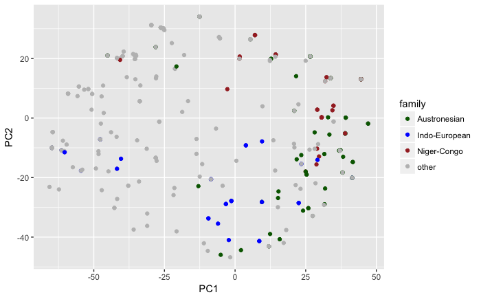

```r
as_tibble(p$x[,1:2], rownames="wals_code") %>%
  mutate(family=wals.554$family) %>%
  mutate(family=if_else(family %in% c("Austronesian", "Indo-European", "Niger-Congo"), family, "other")) %>%
  ggplot(aes(x=PC1, y=PC2, colour=family)) + geom_point() + scale_colour_manual(values=c("darkgreen", "blue", "brown", "gray"))
```